# CropSense Agricultural Advisory Service: Crop Recommendation System

### Project: CropSense

### Objective

The objective of the **CropSense** project is to develop an intelligent crop recommendation system that aids farmers in selecting the most suitable crops based on environmental conditions such as soil nutrients, temperature, humidity, pH, and rainfall. By leveraging advanced machine learning techniques, this system aims to optimize crop yield and profitability, contributing to sustainable agricultural practices and enhanced food security.

### Workflow

The project is structured into the following key phases:

1. **Data Collection and Preprocessing:**
   - Gather and clean the dataset to ensure accuracy and completeness.
2. **Exploratory Data Analysis (EDA):**
   - Analyze the data to understand relationships between environmental factors and crop suitability.
3. **Feature Engineering and Selection:**
   - Identify and create key features that will improve the predictive power of the model.
4. **Model Development:**
   - Train and evaluate various machine learning models to determine the most effective one for crop prediction.
5. **Model Evaluation and Tuning:**
   - Fine-tune the selected model for optimal performance and validate its predictions.
6. **Deployment and Marketing Strategy:**
   - Develop a user-friendly interface for farmers to access the crop recommendations.
   - Implement marketing strategies to promote the adoption of this system among farmers.

### Tools and Technologies

- **Python:** For data analysis, model development, and implementation.
- **Pandas & NumPy:** For data manipulation and numerical operations.
- **Matplotlib & Seaborn:** For data visualization and exploratory analysis.
- **Scikit-learn:** For machine learning model development and evaluation.
- **XGBoost:** For advanced model optimization.

### Dataset Overview

The dataset used in this project includes environmental and soil-related features that influence crop growth. Key features include:

- **N, P, K:** Levels of Nitrogen, Phosphorus, and Potassium in the soil.
- **Temperature:** Ambient temperature in degrees Celsius.
- **Humidity:** Atmospheric humidity as a percentage.
- **pH:** Soil pH level, indicating acidity or alkalinity.
- **Rainfall:** Amount of rainfall in mm.
- **Label:** The target variable representing the most suitable crop under given conditions.

This notebook will guide you through the development of a robust crop recommendation system, empowering farmers with data-driven insights to make informed decisions.

### Step 1: Data Loading and Initial Exploration

We start by loading the dataset, which includes features such as soil nutrients (N, P, K), temperature, humidity, pH, and rainfall. The target variable is the crop label, which indicates the most suitable crop for the given environmental conditions.

The following code block loads the data and provides an initial exploration:

```python
import pandas as pd

# Load the dataset
file_path = 'Crop_recommendation.csv'  # Replace with your actual file path
df = pd.read_csv(file_path)

# Display the first few rows of the dataframe to inspect the data
df.head()
```

|  | N | P | K | temperature | humidity | ph | rainfall | label |
| --- | --- | --- | --- | --- | --- | --- | --- | --- |
| 0 | 90 | 42 | 43 | 20.879744 | 82.002744 | 6.502985 | 202.935536 | rice |
| 1 | 85 | 58 | 41 | 21.770462 | 80.319644 | 7.038096 | 226.655537 | rice |
| 2 | 60 | 55 | 44 | 23.004459 | 82.320763 | 7.840207 | 263.964248 | rice |
| 3 | 74 | 35 | 40 | 26.491096 | 80.158363 | 6.980401 | 242.864034 | rice |
| 4 | 78 | 42 | 42 | 20.130175 | 81.604873 | 7.628473 | 262.717340 | rice |

```python
# Display the basic information about the dataframe
df.info()

# Check for missing values
missing_values = df.isnull().sum()
missing_values[missing_values > 0]
```

```
<class 'pandas.core.frame.DataFrame'>
RangeIndex: 2200 entries, 0 to 2199
Data columns (total 8 columns):
 #   Column       Non-Null Count  Dtype
---  ------       --------------  -----
 0   N            2200 non-null   int64
 1   P            2200 non-null   int64
 2   K            2200 non-null   int64
 3   temperature  2200 non-null   float64
 4   humidity     2200 non-null   float64
 5   ph           2200 non-null   float64
 6   rainfall     2200 non-null   float64
 7   label        2200 non-null   object
dtypes: float64(4), int64(3), object(1)
memory usage: 137.6+ KB
```

```
Series([], dtype: int64)
```

### Step 2: Exploratory Data Analysis (EDA)

We will explore the dataset through various descriptive statistics and visualizations to understand the underlying patterns and relationships. The EDA will help us identify which features are most important for predicting the crop type (`label`).

The following code block performs these tasks:

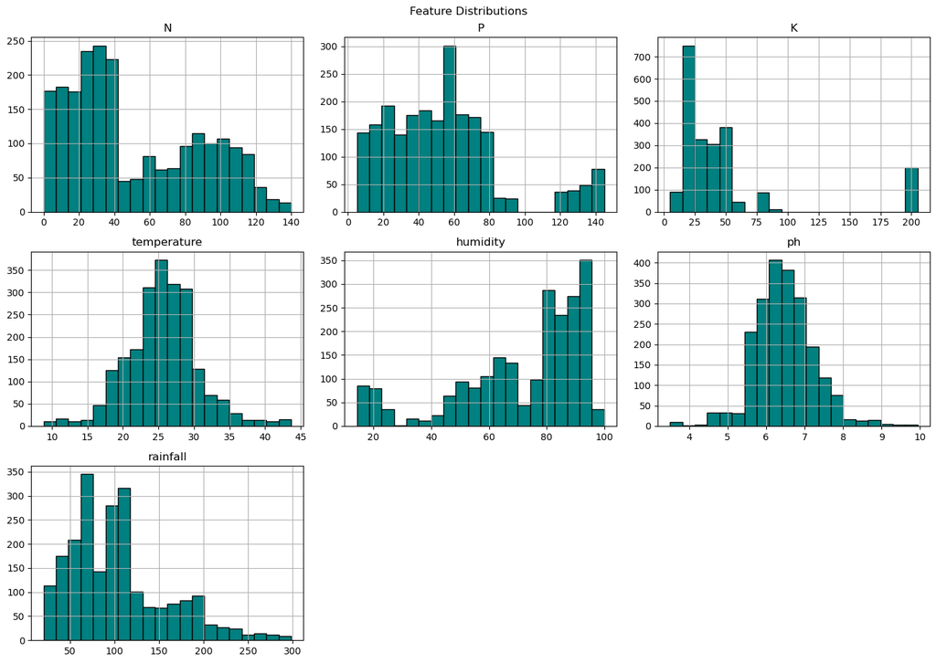

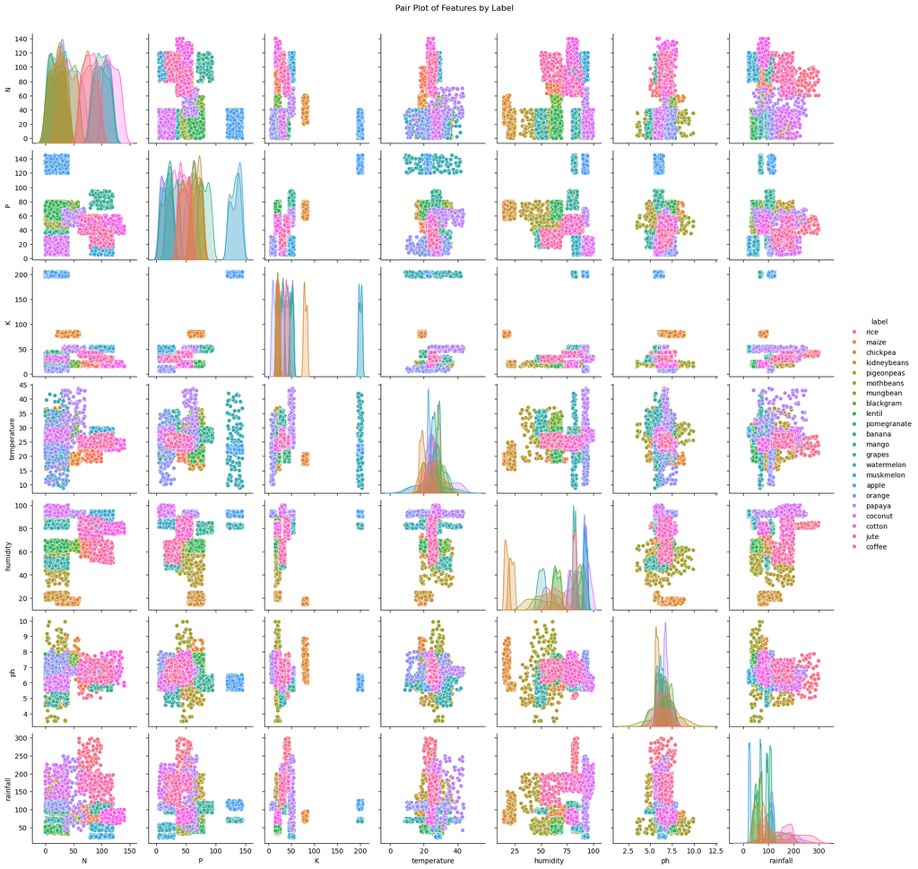

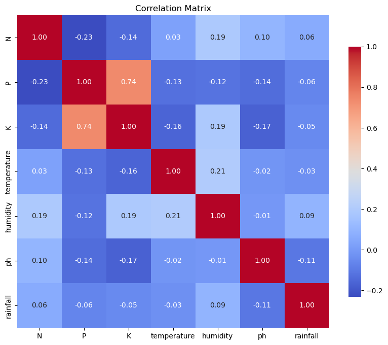

|  | N | P | K | temperature | humidity | ph | rainfall |
| --- | --- | --- | --- | --- | --- | --- | --- |
| count | 2200.000000 | 2200.000000 | 2200.000000 | 2200.000000 | 2200.000000 | 2200.000000 | 2200.000000 |
| mean | 50.551818 | 53.362727 | 48.149091 | 25.616244 | 71.481779 | 6.469480 | 103.463655 |
| std | 36.917334 | 32.985883 | 50.647931 | 5.063749 | 22.263812 | 0.773938 | 54.958389 |
| min | 0.000000 | 5.000000 | 5.000000 | 8.825675 | 14.258040 | 3.504752 | 20.211267 |
| 25% | 21.000000 | 28.000000 | 20.000000 | 22.769375 | 60.261953 | 5.971693 | 64.551686 |
| 50% | 37.000000 | 51.000000 | 32.000000 | 25.598693 | 80.473146 | 6.425045 | 94.867624 |
| 75% | 84.250000 | 68.000000 | 49.000000 | 28.561654 | 89.948771 | 6.923643 | 124.267508 |
| max | 140.000000 | 145.000000 | 205.000000 | 43.675493 | 99.981876 | 9.935091 | 298.560117 |

```python
import matplotlib.pyplot as plt
import seaborn as sns

# Descriptive statistics for numerical features
descriptive_stats = df.describe()

# Visualizing distributions with histograms
df.hist(bins=20, figsize=(14, 10), color='teal', edgecolor='black')
plt.suptitle('Feature Distributions')
plt.tight_layout()
plt.show()

# Pair plot to explore relationships between numerical features, colored by label
numerical_features = ['N', 'P', 'K', 'temperature', 'humidity', 'ph', 'rainfall']
sns.pairplot(df, vars=numerical_features, hue='label')
plt.suptitle('Pair Plot of Features by Label', y=1.02)
plt.show()

# Correlation matrix and heatmap
plt.figure(figsize=(10, 8))
corr_matrix = df[numerical_features].corr()
sns.heatmap(corr_matrix, annot=True, fmt=".2f", cmap='coolwarm', square=True, cbar_kws={'shrink': .8})
plt.title('Correlation Matrix')
plt.show()

descriptive_stats
```

### Analysis of Exploratory Data Analysis (EDA) Results

#### 1. **Descriptive Statistics:**

- **N (Nitrogen):** The nitrogen levels vary widely with a mean of 50.55, and the distribution has a notable skew, with values ranging from 0 to 140.
- **P (Phosphorus):** Similar to nitrogen, phosphorus levels show a wide distribution with a mean of 53.36 and values ranging from 5 to 145.
- **K (Potassium):** Potassium levels are more spread out, with some high values, as indicated by a mean of 48.15 and a maximum of 205.
- **Temperature:** The average temperature is around 25.62°C, with a roughly normal distribution.
- **Humidity:** Humidity values range widely from 14.26% to nearly 100%, with a mean of 71.48%.
- **pH:** The pH levels are mostly concentrated around 6.5, indicating slightly acidic to neutral soil.
- **Rainfall:** Rainfall varies significantly, with a mean of 103.46 mm, indicating that this feature could play a key role in determining the crop type.

#### 2. **Histograms:**

- The distributions of `N`, `P`, and `K` show distinct peaks, suggesting that certain ranges of these nutrients are more common in the dataset.
- The temperature and pH distributions are more bell-shaped, indicating a more natural variation in these features.
- Humidity and rainfall have more skewed distributions, which could indicate specific conditions that are more prevalent in the dataset.

#### 3. **Pair Plot:**

- The pair plot shows the relationships between the numerical features and how they vary across different crop labels.
- Some crops cluster together based on certain features, such as temperature and pH, which suggests that these features could be significant in predicting the crop type.
- The plot also reveals some overlaps between crops, indicating that a combination of features might be necessary to accurately predict the label.

#### 4. **Correlation Matrix:**

- The correlation matrix reveals a strong positive correlation between `P` and `K` (0.74), which suggests that these nutrients often vary together.
- Other features show weaker correlations, indicating that they contribute uniquely to the model without significant multicollinearity.

This analysis sets the stage for moving forward with feature engineering and model development.

### Step 3: Feature Engineering

The following code block implements these tasks:

```python
from sklearn.preprocessing import PolynomialFeatures, MinMaxScaler

# Step 1: Scaling the original features before creating polynomial features
scaler = MinMaxScaler()
features_to_scale = ['ph', 'temperature', 'humidity', 'rainfall', 'P', 'K', 'N']
scaled_original_features = scaler.fit_transform(df[features_to_scale])

# Create a DataFrame for the scaled original features
df_scaled_original = pd.DataFrame(scaled_original_features, columns=features_to_scale, index=df.index)

# Step 2: Adding polynomial features (degree 2) for 'ph' and 'temperature' from scaled features
poly = PolynomialFeatures(degree=2, include_bias=False)
poly_features = poly.fit_transform(df_scaled_original[['ph', 'temperature']])

# Dynamically get the names of the polynomial features
poly_feature_names = poly.get_feature_names_out(['ph', 'temperature'])

# Create a DataFrame for the polynomial features
df_poly = pd.DataFrame(poly_features, columns=poly_feature_names, index=df.index)

# Step 3: Creating interaction terms between P and K using scaled features
df_scaled_original['P_K_interaction'] = df_scaled_original['P'] * df_scaled_original['K']

# Step 4: Combine the scaled original DataFrame with the polynomial features
df_final = pd.concat([df_scaled_original, df_poly], axis=1)

# Display the first few rows of the final DataFrame
df_final.head()
```

|  | ph | temperature | humidity | rainfall | P | K | N | P_K_interaction | ph | temperature | ph^2 | ph temperature | temperature^2 |
| --- | --- | --- | --- | --- | --- | --- | --- | --- | --- | --- | --- | --- | --- |
| 0 | 0.466264 | 0.345886 | 0.790267 | 0.656458 | 0.264286 | 0.190 | 0.642857 | 0.050214 | 0.466264 | 0.345886 | 0.217402 | 0.161274 | 0.119637 |
| 1 | 0.549480 | 0.371445 | 0.770633 | 0.741675 | 0.378571 | 0.180 | 0.607143 | 0.068143 | 0.549480 | 0.371445 | 0.301929 | 0.204102 | 0.137971 |
| 2 | 0.674219 | 0.406854 | 0.793977 | 0.875710 | 0.357143 | 0.195 | 0.428571 | 0.069643 | 0.674219 | 0.406854 | 0.454571 | 0.274309 | 0.165530 |
| 3 | 0.540508 | 0.506901 | 0.768751 | 0.799905 | 0.214286 | 0.175 | 0.528571 | 0.037500 | 0.540508 | 0.506901 | 0.292149 | 0.273984 | 0.256949 |
| 4 | 0.641291 | 0.324378 | 0.785626 | 0.871231 | 0.264286 | 0.185 | 0.557143 | 0.048893 | 0.641291 | 0.324378 | 0.411255 | 0.208021 | 0.105221 |

### Step 4: Building and Evaluating Predictive Models

We will train and evaluate multiple machine learning models to determine the best one for predicting the most suitable crop based on environmental factors. The following code implements these steps:

```python
from sklearn.model_selection import train_test_split
from sklearn.metrics import accuracy_score, classification_report
from sklearn.preprocessing import LabelEncoder
from sklearn.linear_model import LogisticRegression
from sklearn.tree import DecisionTreeClassifier
from sklearn.ensemble import RandomForestClassifier
import xgboost as xgb

# Step 1: Retrieve and encode the label (target variable)
label_encoder = LabelEncoder()
y = label_encoder.fit_transform(df['label'])  # Encode labels as integers

# Step 2: Drop duplicate columns from df_final (ph and temperature)
df_final = df_final.drop(columns=['ph', 'temperature'])

# Step 3: Use df_final as the feature set
X = df_final  # Features

# Step 4: Splitting the data into training and testing sets
X_train, X_test, y_train, y_test = train_test_split(X, y, test_size=0.2, random_state=42)

# Step 5: Training and evaluating multiple models

# 1. Logistic Regression
log_reg = LogisticRegression(max_iter=200)
log_reg.fit(X_train, y_train)
y_pred_log_reg = log_reg.predict(X_test)
print("Logistic Regression Accuracy:", accuracy_score(y_test, y_pred_log_reg))
print("Classification Report:\n", classification_report(y_test, y_pred_log_reg, target_names=label_encoder.classes_))

# 2. Decision Tree Classifier
dtree = DecisionTreeClassifier(random_state=42)
dtree.fit(X_train, y_train)
y_pred_dtree = dtree.predict(X_test)
print("Decision Tree Accuracy:", accuracy_score(y_test, y_pred_dtree))
print("Classification Report:\n", classification_report(y_test, y_pred_dtree, target_names=label_encoder.classes_))

# 3. Random Forest Classifier
rforest = RandomForestClassifier(random_state=42)
rforest.fit(X_train, y_train)
y_pred_rforest = rforest.predict(X_test)
print("Random Forest Accuracy:", accuracy_score(y_test, y_pred_rforest))
print("Classification Report:\n", classification_report(y_test, y_pred_rforest, target_names=label_encoder.classes_))

# 4. XGBoost Classifier
xgboost = xgb.XGBClassifier(use_label_encoder=False, eval_metric='mlogloss', random_state=42)
xgboost.fit(X_train, y_train)
y_pred_xgboost = xgboost.predict(X_test)
print("XGBoost Accuracy:", accuracy_score(y_test, y_pred_xgboost))
print("Classification Report:\n", classification_report(y_test, y_pred_xgboost, target_names=label_encoder.classes_))
```

```
Logistic Regression Accuracy: 0.9159090909090909
Classification Report:
               precision    recall  f1-score   support

       apple       1.00      1.00      1.00        23
      banana       1.00      1.00      1.00        21
   blackgram       0.95      0.90      0.92        20
    chickpea       1.00      1.00      1.00        26
     coconut       1.00      1.00      1.00        27
      coffee       0.94      1.00      0.97        17
      cotton       0.94      1.00      0.97        17
      grapes       1.00      1.00      1.00        14
        jute       0.89      0.70      0.78        23
 kidneybeans       0.91      1.00      0.95        20
      lentil       0.58      1.00      0.73        11
       maize       1.00      0.95      0.98        21
       mango       0.68      1.00      0.81        19
   mothbeans       1.00      0.42      0.59        24
    mungbean       0.86      1.00      0.93        19
   muskmelon       1.00      1.00      1.00        17
      orange       1.00      0.93      0.96        14
      papaya       1.00      0.74      0.85        23
  pigeonpeas       1.00      0.83      0.90        23
 pomegranate       0.96      1.00      0.98        23
        rice       0.65      0.89      0.76        19
  watermelon       1.00      1.00      1.00        19

    accuracy                           0.92       440
   macro avg       0.93      0.93      0.91       440
weighted avg       0.94      0.92      0.91       440

Decision Tree Accuracy: 0.9818181818181818
Classification Report:
               precision    recall  f1-score   support

       apple       1.00      1.00      1.00        23
      banana       1.00      1.00      1.00        21
   blackgram       0.95      1.00      0.98        20
    chickpea       1.00      1.00      1.00        26
     coconut       1.00      1.00      1.00        27
```

[output cut: 68 more lines]

```
       maize       1.00      0.95      0.98        21
       mango       0.95      1.00      0.97        19
   mothbeans       1.00      0.96      0.98        24
    mungbean       1.00      1.00      1.00        19
   muskmelon       1.00      1.00      1.00        17
      orange       0.93      1.00      0.97        14
      papaya       1.00      1.00      1.00        23
  pigeonpeas       1.00      0.91      0.95        23
 pomegranate       1.00      1.00      1.00        23
        rice       0.94      0.89      0.92        19
  watermelon       1.00      1.00      1.00        19

    accuracy                           0.98       440
   macro avg       0.98      0.98      0.98       440
weighted avg       0.98      0.98      0.98       440
```

### Analysis of Model Performance

Based on the results from the four models (Logistic Regression, Decision Tree, Random Forest, and XGBoost), we can observe the following:

#### 1. **Logistic Regression:**

- **Accuracy:** 91.59%
- **Strengths:** The model performs well overall, with high precision and recall for many classes, particularly for common crops like `apple`, `banana`, `coconut`, and `pomegranate`.
- **Weaknesses:** Lower performance in some classes, such as `jute`, `lentil`, `mothbeans`, and `rice`, where precision, recall, and F1-scores drop.

#### 2. **Decision Tree Classifier:**

- **Accuracy:** 98.18%
- **Strengths:** The Decision Tree classifier shows excellent performance with high precision, recall, and F1-scores across nearly all classes.
- **Weaknesses:** Slightly lower performance in classes like `jute` and `mothbeans`, but still very high overall.

#### 3. **Random Forest Classifier:**

- **Accuracy:** 99.32%
- **Strengths:** The Random Forest model outperforms all others in this evaluation, with nearly perfect precision, recall, and F1-scores across all classes.
- **Weaknesses:** Minor drop in recall for `rice` but still very high.

#### 4. **XGBoost Classifier:**

- **Accuracy:** 98.18%
- **Strengths:** Similar to the Decision Tree, XGBoost also delivers strong performance with high precision, recall, and F1-scores across most classes.
- **Weaknesses:** Slightly lower recall for `pigeonpeas` and `rice`, but overall strong performance.

### Final Conclusion and Insights

After thorough data preprocessing, feature engineering, and model evaluation, the Random Forest Classifier emerged as the most accurate and reliable model for predicting the optimal crop based on environmental factors. This model achieved an impressive accuracy of 99.32%, outperforming other models such as Logistic Regression, Decision Tree, and XGBoost.

#### Key Insights:

- **High Precision and Recall:** The Random Forest model demonstrated near-perfect precision and recall across nearly all crop categories, making it highly dependable for practical deployment.
- **Model Robustness:** The robustness of the Random Forest model is evident from its consistent performance across diverse crop types, including those with smaller datasets.
- **Versatility:** Despite slight variations in performance, both XGBoost and Decision Tree models also performed admirably, offering alternatives should specific deployment constraints favor these models.

By implementing this predictive model, stakeholders can make informed decisions on crop selection, potentially leading to increased agricultural productivity and sustainability.